# WeRateDogs Data Exploration

# Gathering Data

*1Importing the twitter archive data

*Importing the tweet image prediction data

*Importing Twitter API Data

## Assessing Data

*Quality Issues

*Tidiness Issues

# Cleaning Data

*Cleaning Twitter Archive

*Claening Tweet Image Prediction

*Cleaning tweet data from Twitter API

*Merge the datasets

# Analyzing and Visualizing Data

# INTRODUCTION

This is a data wrangle report that demonstrates the data wrangling process for the tweet archive of Twitter user @dog_rates,

also known as WeRateDogs. WeRateDogs is a Twitter account that rates people's dogs with a humorous comment about the dog.

These ratings almost always have a denominator of 10.

```python
# Import statements for packages used in project
import matplotlib.pyplot as plt
%matplotlib inline
from matplotlib.dates import DateFormatter
import tweepy
from tweepy import OAuthHandler
import json
import pandas as pd
import numpy as np
import requests
import os
import seaborn as sns
from timeit import default_timer as timer
import PIL.Image
from io import BytesIO
from PIL import Image
```

# GATHERING DATA

In the cell below gather all three pieces of data for this project and load them in the note book

Note the methods required to gather each data are different

1. Directly download the WeRateDogs Twitter archive data (twitter_archive_enhanced.csv)

```python
# loading the WeRateDogs Twitter archive data
twitter_archive = pd.read_csv('twitter-archive-enhanced.csv', sep =',')
```

1. Use the Requests library to download the tweet image prediction(image_predictions.tsv)

```python
# link of the tweet image prediction
url = 'https://d17h27t6h515a5.cloudfront.net/topher/2017/August/599fd2ad_image-predictions/image-predictions.tsv'


# Getting response from the request
request = requests.get(url)
request
```

```
<Response [200]>
```

```python
# get file with the image predictions
with open('image-predictions.tsv' , 'wb') as file:
    predictions = requests.get(url)
    file.write(predictions.content)
```

```python
#load image prediction
image_predictions = pd.read_csv('image-predictions.tsv', sep='\t')
```

```python
# the first five rows
image_predictions.head()
```

|  | tweet_id | jpg_url | img_num | p1 | p1_conf | p1_dog | p2 | p2_conf | p2_dog | p3 | p3_conf | p3_dog |
| --- | --- | --- | --- | --- | --- | --- | --- | --- | --- | --- | --- | --- |
| 0 | 666020888022790149 | https://pbs.twimg.com/media/CT4udn0WwAA0aMy.jpg | 1 | Welsh_springer_spaniel | 0.465074 | True | collie | 0.156665 | True | Shetland_sheepdog | 0.061428 | True |
| 1 | 666029285002620928 | https://pbs.twimg.com/media/CT42GRgUYAA5iDo.jpg | 1 | redbone | 0.506826 | True | miniature_pinscher | 0.074192 | True | Rhodesian_ridgeback | 0.072010 | True |
| 2 | 666033412701032449 | https://pbs.twimg.com/media/CT4521TWwAEvMyu.jpg | 1 | German_shepherd | 0.596461 | True | malinois | 0.138584 | True | bloodhound | 0.116197 | True |
| 3 | 666044226329800704 | https://pbs.twimg.com/media/CT5Dr8HUEAA-lEu.jpg | 1 | Rhodesian_ridgeback | 0.408143 | True | redbone | 0.360687 | True | miniature_pinscher | 0.222752 | True |
| 4 | 666049248165822465 | https://pbs.twimg.com/media/CT5IQmsXIAAKY4A.jpg | 1 | miniature_pinscher | 0.560311 | True | Rottweiler | 0.243682 | True | Doberman | 0.154629 | True |

```python
#importing tweepy to get authorization access to Twitter API data, json will be used to store data in JSON format and timeit
#to check wait on rate limit

consumer_key = ''
consumer_secret = ''
access_token =  ''
access_secret = ''

auth = tweepy.OAuthHandler(consumer_key, consumer_secret)
auth.set_access_token(access_token, access_secret)

api = tweepy.API(auth)

# Tweet IDs for which would be used to query Twitter API for additional data
tweet_ids = twitter_archive.tweet_id.values

# querying Twitter API for additional data using the tweet_ids variable
count = 0
fails_dict = {}
start = timer()

# Saving each tweet's returned JSON as a new line in a .txt file
with open('tweet_json.txt', 'w') as outfile:
    for tweet_id in tweet_ids:
        count += 1
        print(str(count) + ": " + str(tweet_id))
        try:
            tweet = api.get_status(tweet_id, tweet_mode='extended')
            print("Success")
            json.dump([tweet._json], outfile)
            outfile.write('\n')
        except tweepy.TweepyException as e:
            print("Fail")
            fails_dict[tweet_id] = e
            pass

end = timer()
print(end - start)
print(fails_dict)
# reading the file line by line to get each json data and store in a list
```

[output not shown]

[output cut: 4659 more lines]

[output not shown]

```python
#writing the  JSON data to the required tweet_json.txt file with each tweet's JSON data on its own line.

# read this file, line by line, to create a pandas DataFrame

df_list =[]
with open('tweet-json.txt', 'r') as file:
    for line in file:
        tweets = json.loads(line)
        tweet_id = tweets['id']
        retweet_count = tweets['retweet_count']
        favorite_count = tweets['favorite_count']
        df_list.append({'tweet_id': str(tweet_id),
                             'favorite_count': int(favorite_count),
                             'retweet_count': int(retweet_count)})
tweet_data = pd.DataFrame(df_list, columns = ['tweet_id', 'favorite_count','retweet_count'])
```

```python
tweet_data
```

|  | tweet_id | favorite_count | retweet_count |
| --- | --- | --- | --- |
| 0 | 892420643555336193 | 39467 | 8853 |
| 1 | 892177421306343426 | 33819 | 6514 |
| 2 | 891815181378084864 | 25461 | 4328 |
| 3 | 891689557279858688 | 42908 | 8964 |
| 4 | 891327558926688256 | 41048 | 9774 |
| ... | ... | ... | ... |
| 2349 | 666049248165822465 | 111 | 41 |
| 2350 | 666044226329800704 | 311 | 147 |
| 2351 | 666033412701032449 | 128 | 47 |
| 2352 | 666029285002620928 | 132 | 48 |
| 2353 | 666020888022790149 | 2535 | 532 |

2354 rows × 3 columns

# ASSESSING THE DATA

Visual Assessment

```python
# showing a random sample of the dataset
twitter_archive.sample(20)
```

|  | tweet_id | in_reply_to_status_id | in_reply_to_user_id | timestamp | source | text | retweeted_status_id | retweeted_status_user_id | retweeted_status_timestamp | expanded_urls | rating_numerator | rating_denominator | name | doggo | floofer | pupper | puppo |
| --- | --- | --- | --- | --- | --- | --- | --- | --- | --- | --- | --- | --- | --- | --- | --- | --- | --- |
| 504 | 813051746834595840 | NaN | NaN | 2016-12-25 16:00:16 +0000 | <a href="http://twitter.com/download/iphone" r... | This is Bauer. He had nothing to do with the c... | NaN | NaN | NaN | https://twitter.com/dog_rates/status/813051746... | 13 | 10 | Bauer | None | None | None | None |
| 2057 | 671355857343524864 | NaN | NaN | 2015-11-30 15:51:24 +0000 | <a href="http://twitter.com/download/iphone" r... | This is Lou. He's a Petrarch Sunni Pinto. Well... | NaN | NaN | NaN | https://twitter.com/dog_rates/status/671355857... | 10 | 10 | Lou | None | None | None | None |
| 990 | 748705597323898880 | NaN | NaN | 2016-07-01 02:31:39 +0000 | <a href="http://twitter.com" rel="nofollow">Tw... | #BarkWeek is getting rather heckin terrifying ... | NaN | NaN | NaN | https://twitter.com/dog_rates/status/748705597... | 13 | 10 | None | None | None | None | None |
| 331 | 832998151111966721 | NaN | NaN | 2017-02-18 17:00:10 +0000 | <a href="http://twitter.com/download/iphone" r... | This is Rhino. He arrived at a shelter with an... | NaN | NaN | NaN | https://twitter.com/dog_rates/status/832998151... | 13 | 10 | Rhino | doggo | None | None | None |
| 800 | 772615324260794368 | NaN | NaN | 2016-09-05 02:00:22 +0000 | <a href="http://twitter.com/download/iphone" r... | RT @dog_rates: This is Gromit. He's pupset bec... | 7.652221e+17 | 4.196984e+09 | 2016-08-15 16:22:20 +0000 | https://twitter.com/dog_rates/status/765222098... | 10 | 10 | Gromit | None | None | None | None |
| 1004 | 747816857231626240 | NaN | NaN | 2016-06-28 15:40:07 +0000 | <a href="http://twitter.com/download/iphone" r... | Viewer discretion is advised. This is a terrib... | NaN | NaN | NaN | https://twitter.com/dog_rates/status/747816857... | 4 | 10 | a | None | None | None | None |
| 1238 | 712097430750289920 | NaN | NaN | 2016-03-22 02:03:52 +0000 | <a href="http://twitter.com/download/iphone" r... | I can't even comprehend how confused this dog ... | NaN | NaN | NaN | https://twitter.com/dog_rates/status/712097430... | 10 | 10 | None | None | None | None | None |
| 1084 | 738402415918125056 | NaN | NaN | 2016-06-02 16:10:29 +0000 | <a href="http://twitter.com/download/iphone" r... | "Don't talk to me or my son ever again" ...10/... | NaN | NaN | NaN | https://twitter.com/dog_rates/status/738402415... | 10 | 10 | None | None | None | None | None |
| 624 | 795464331001561088 | NaN | NaN | 2016-11-07 03:14:10 +0000 | <a href="http://twitter.com/download/iphone" r... | Elder doggo does a splash. Both 13/10 incredib... | NaN | NaN | NaN | https://twitter.com/dog_rates/status/795464331... | 13 | 10 | None | doggo | None | None | None |
| 647 | 793135492858580992 | NaN | NaN | 2016-10-31 17:00:11 +0000 | <a href="http://twitter.com/download/iphone" r... | Your favorite squad is looking extra h*ckin sp... | NaN | NaN | NaN | https://twitter.com/dog_rates/status/793135492... | 13 | 10 | None | None | None | None | None |
| 1072 | 739979191639244800 | NaN | NaN | 2016-06-07 00:36:02 +0000 | <a href="http://twitter.com/download/iphone" r... | This is Nollie. She's waving at you. If you do... | NaN | NaN | NaN | https://twitter.com/dog_rates/status/739979191... | 12 | 10 | Nollie | None | None | None | None |
| 1468 | 694206574471057408 | NaN | NaN | 2016-02-01 17:11:59 +0000 | <a href="http://twitter.com/download/iphone" r... | "Martha come take a look at this. I'm so fed u... | NaN | NaN | NaN | https://twitter.com/dog_rates/status/694206574... | 10 | 10 | None | None | None | None | None |
| 278 | 840268004936019968 | NaN | NaN | 2017-03-10 18:27:58 +0000 | <a href="http://twitter.com/download/iphone" r... | This is Monty. He makes instantly regrettable ... | NaN | NaN | NaN | https://twitter.com/dog_rates/status/840268004... | 12 | 10 | Monty | None | None | None | None |
| 1791 | 677335745548390400 | NaN | NaN | 2015-12-17 03:53:20 +0000 | <a href="http://vine.co" rel="nofollow">Vine -... | Downright inspiring 12/10 https://t.co/vSLtYBWHcQ | NaN | NaN | NaN | https://vine.co/v/hbLbH77Ar67 | 12 | 10 | None | None | None | None | None |
| 627 | 794983741416415232 | NaN | NaN | 2016-11-05 19:24:28 +0000 | <a href="http://twitter.com/download/iphone" r... | RT @dog_rates: This is Rizzy. She smiles a lot... | 7.895309e+17 | 4.196984e+09 | 2016-10-21 18:16:44 +0000 | https://twitter.com/dog_rates/status/789530877... | 12 | 10 | Rizzy | None | None | None | None |
| 240 | 846514051647705089 | NaN | NaN | 2017-03-28 00:07:32 +0000 | <a href="http://twitter.com/download/iphone" r... | This is Barney. He's an elder doggo. Hitches a... | NaN | NaN | NaN | https://twitter.com/dog_rates/status/846514051... | 13 | 10 | Barney | doggo | None | None | None |
| 1840 | 675888385639251968 | NaN | NaN | 2015-12-13 04:02:03 +0000 | <a href="http://twitter.com/download/iphone" r... | Breathtaking scene. A father taking care of hi... | NaN | NaN | NaN | https://twitter.com/dog_rates/status/675888385... | 10 | 10 | None | None | None | None | None |
| 944 | 752682090207055872 | NaN | NaN | 2016-07-12 01:52:49 +0000 | <a href="http://twitter.com/download/iphone" r... | Nothing better than a doggo and a sunset. 10/1... | NaN | NaN | NaN | https://twitter.com/dog_rates/status/752682090... | 10 | 10 | None | doggo | None | None | None |
| 519 | 810284430598270976 | NaN | NaN | 2016-12-18 00:43:57 +0000 | <a href="http://twitter.com/download/iphone" r... | This is Phil. He's a father. A very good fathe... | NaN | NaN | NaN | https://twitter.com/dog_rates/status/810284430... | 13 | 10 | Phil | None | None | None | None |
| 1226 | 713919462244790272 | NaN | NaN | 2016-03-27 02:43:58 +0000 | <a href="http://twitter.com/download/iphone" r... | This is Kanu. He's a Freckled Ticonderoga. Sim... | NaN | NaN | NaN | https://twitter.com/dog_rates/status/713919462... | 12 | 10 | Kanu | None | None | None | None |

```python
image_predictions.sample(20)
```

|  | tweet_id | jpg_url | img_num | p1 | p1_conf | p1_dog | p2 | p2_conf | p2_dog | p3 | p3_conf | p3_dog |
| --- | --- | --- | --- | --- | --- | --- | --- | --- | --- | --- | --- | --- |
| 1875 | 845677943972139009 | https://pbs.twimg.com/media/C7xzmngWkAAAp9C.jpg | 1 | chow | 0.808681 | True | groenendael | 0.123141 | True | Newfoundland | 0.022143 | True |
| 651 | 682003177596559360 | https://pbs.twimg.com/media/CXb2RcDUsAEnkJb.jpg | 1 | triceratops | 0.249872 | False | chimpanzee | 0.060929 | False | mask | 0.050221 | False |
| 1720 | 819347104292290561 | https://pbs.twimg.com/media/C17n1nrWQAIErU3.jpg | 3 | Rottweiler | 0.909106 | True | black-and-tan_coonhound | 0.044120 | True | Doberman | 0.031835 | True |
| 1026 | 710833117892898816 | https://pbs.twimg.com/media/Cd1i8qvUkAE-Jlr.jpg | 1 | Pembroke | 0.803742 | True | Cardigan | 0.189712 | True | German_shepherd | 0.001746 | True |
| 1312 | 754482103782404096 | https://pbs.twimg.com/ext_tw_video_thumb/75448... | 1 | tub | 0.596796 | False | bathtub | 0.381098 | False | shower_curtain | 0.017629 | False |
| 2058 | 888917238123831296 | https://pbs.twimg.com/media/DFYRgsOUQAARGhO.jpg | 1 | golden_retriever | 0.714719 | True | Tibetan_mastiff | 0.120184 | True | Labrador_retriever | 0.105506 | True |
| 941 | 704054845121142784 | https://pbs.twimg.com/media/CcVOJEcXEAM0FHL.jpg | 1 | Great_Pyrenees | 0.667939 | True | kuvasz | 0.228764 | True | golden_retriever | 0.043885 | True |
| 1745 | 822975315408461824 | https://pbs.twimg.com/media/C2vLrpvWIAA3LM3.jpg | 1 | bathtub | 0.331098 | False | tub | 0.248860 | False | Pembroke | 0.233162 | True |
| 23 | 666345417576210432 | https://pbs.twimg.com/media/CT9Vn7PWoAA_ZCM.jpg | 1 | golden_retriever | 0.858744 | True | Chesapeake_Bay_retriever | 0.054787 | True | Labrador_retriever | 0.014241 | True |
| 423 | 674053186244734976 | https://pbs.twimg.com/media/CVq3zAaWwAA8vpk.jpg | 1 | Cardigan | 0.984725 | True | Pembroke | 0.008730 | True | kelpie | 0.002195 | True |
| 746 | 687664829264453632 | https://pbs.twimg.com/media/CYsTg1XUsAEPjxE.jpg | 1 | pug | 0.957365 | True | French_bulldog | 0.038559 | True | toy_poodle | 0.000667 | True |
| 1551 | 793135492858580992 | https://pbs.twimg.com/media/CwHIg61WIAApnEV.jpg | 1 | bakery | 0.737041 | False | saltshaker | 0.052396 | False | teddy | 0.046593 | False |
| 11 | 666071193221509120 | https://pbs.twimg.com/media/CT5cN_3WEAAlOoZ.jpg | 1 | Gordon_setter | 0.503672 | True | Yorkshire_terrier | 0.174201 | True | Pekinese | 0.109454 | True |
| 914 | 700890391244103680 | https://pbs.twimg.com/media/CboQFolWIAE04qE.jpg | 1 | white_wolf | 0.166563 | False | schipperke | 0.122356 | True | West_Highland_white_terrier | 0.119247 | True |
| 993 | 708119489313951744 | https://pbs.twimg.com/media/CdO-6x5W8AENSBJ.jpg | 1 | Norwich_terrier | 0.264483 | True | Norfolk_terrier | 0.258786 | True | chow | 0.096899 | True |
| 2017 | 880095782870896641 | https://pbs.twimg.com/media/DDa6ckbXgAAM1vV.jpg | 1 | miniature_pinscher | 0.120298 | True | Rhodesian_ridgeback | 0.106395 | True | beagle | 0.106073 | True |
| 552 | 677565715327688705 | https://pbs.twimg.com/media/CWcybBmWcAAigAQ.jpg | 1 | basset | 0.397295 | True | Welsh_springer_spaniel | 0.199554 | True | purse | 0.105641 | False |
| 1060 | 715009755312439296 | https://pbs.twimg.com/media/Cew5kyOWsAA8Y_o.jpg | 1 | dingo | 0.310903 | False | Chihuahua | 0.142288 | True | Cardigan | 0.103945 | True |
| 410 | 673887867907739649 | https://pbs.twimg.com/media/CVoha_IU4AAZ7vi.jpg | 2 | Brabancon_griffon | 0.216767 | True | Chihuahua | 0.190958 | True | golden_retriever | 0.163288 | True |
| 716 | 685641971164143616 | https://pbs.twimg.com/media/CYPjvFqW8AAgiP2.jpg | 1 | Lakeland_terrier | 0.253839 | True | Airedale | 0.213349 | True | three-toed_sloth | 0.083834 | False |

```python
#getting sample 20 rows
tweet_data.sample(20)
```

|  | tweet_id | favorite_count | retweet_count |
| --- | --- | --- | --- |
| 436 | 820078625395449857 | 21979 | 7246 |
| 313 | 835172783151792128 | 28552 | 6516 |
| 752 | 778774459159379968 | 0 | 11550 |
| 54 | 881633300179243008 | 129 | 7 |
| 463 | 817415592588222464 | 6267 | 1131 |
| 1230 | 713175907180089344 | 4851 | 1630 |
| 1775 | 677918531514703872 | 1476 | 463 |
| 764 | 777885040357281792 | 7078 | 1893 |
| 1408 | 699036661657767936 | 2863 | 1345 |
| 2092 | 670778058496974848 | 345 | 77 |
| 1041 | 743835915802583040 | 0 | 2387 |
| 1941 | 673709992831262724 | 908 | 306 |
| 1515 | 690938899477221376 | 4536 | 2245 |
| 1039 | 743980027717509120 | 4551 | 1231 |
| 1761 | 678446151570427904 | 4358 | 1785 |
| 1231 | 712809025985978368 | 20378 | 7602 |
| 2318 | 666437273139982337 | 131 | 52 |
| 1102 | 735137028879360001 | 3428 | 1092 |
| 1789 | 677335745548390400 | 3328 | 2017 |
| 685 | 788070120937619456 | 0 | 3952 |

Programmatic Assessment

Pandas'functions or methods are used to assess the data.

```python
#check the data type,column names
twitter_archive.info()
```

```
<class 'pandas.core.frame.DataFrame'>
RangeIndex: 2356 entries, 0 to 2355
Data columns (total 17 columns):
 #   Column                      Non-Null Count  Dtype
---  ------                      --------------  -----
 0   tweet_id                    2356 non-null   int64
 1   in_reply_to_status_id       78 non-null     float64
 2   in_reply_to_user_id         78 non-null     float64
 3   timestamp                   2356 non-null   object
 4   source                      2356 non-null   object
 5   text                        2356 non-null   object
 6   retweeted_status_id         181 non-null    float64
 7   retweeted_status_user_id    181 non-null    float64
 8   retweeted_status_timestamp  181 non-null    object
 9   expanded_urls               2297 non-null   object
 10  rating_numerator            2356 non-null   int64
 11  rating_denominator          2356 non-null   int64
 12  name                        2356 non-null   object
 13  doggo                       2356 non-null   object
 14  floofer                     2356 non-null   object
 15  pupper                      2356 non-null   object
 16  puppo                       2356 non-null   object
dtypes: float64(4), int64(3), object(10)
memory usage: 313.0+ KB
```

```python
#initial statistics of the data
twitter_archive.describe()
```

|  | tweet_id | in_reply_to_status_id | in_reply_to_user_id | retweeted_status_id | retweeted_status_user_id | rating_numerator | rating_denominator |
| --- | --- | --- | --- | --- | --- | --- | --- |
| count | 2.356000e+03 | 7.800000e+01 | 7.800000e+01 | 1.810000e+02 | 1.810000e+02 | 2356.000000 | 2356.000000 |
| mean | 7.427716e+17 | 7.455079e+17 | 2.014171e+16 | 7.720400e+17 | 1.241698e+16 | 13.126486 | 10.455433 |
| std | 6.856705e+16 | 7.582492e+16 | 1.252797e+17 | 6.236928e+16 | 9.599254e+16 | 45.876648 | 6.745237 |
| min | 6.660209e+17 | 6.658147e+17 | 1.185634e+07 | 6.661041e+17 | 7.832140e+05 | 0.000000 | 0.000000 |
| 25% | 6.783989e+17 | 6.757419e+17 | 3.086374e+08 | 7.186315e+17 | 4.196984e+09 | 10.000000 | 10.000000 |
| 50% | 7.196279e+17 | 7.038708e+17 | 4.196984e+09 | 7.804657e+17 | 4.196984e+09 | 11.000000 | 10.000000 |
| 75% | 7.993373e+17 | 8.257804e+17 | 4.196984e+09 | 8.203146e+17 | 4.196984e+09 | 12.000000 | 10.000000 |
| max | 8.924206e+17 | 8.862664e+17 | 8.405479e+17 | 8.874740e+17 | 7.874618e+17 | 1776.000000 | 170.000000 |

```python
#shape of data the columns and rows
twitter_archive.shape
```

```
(2356, 17)
```

```python
twitter_archive.rating_denominator.value_counts().sort_index(ascending = False)
```

```
170       1
150       1
130       1
120       1
110       1
90        1
80        2
70        1
50        3
40        1
20        2
16        1
15        1
11        3
10     2333
7         1
2         1
0         1
Name: rating_denominator, dtype: int64
```

```python
# the frequency of the  various name
twitter_archive.name.value_counts()
```

```
None        745
a            55
Charlie      12
Cooper       11
Oliver       11
           ...
Joey          1
Timber        1
Pubert        1
Florence      1
Autumn        1
Name: name, Length: 957, dtype: int64
```

```python
# total duplicated
twitter_archive.duplicated().sum()
```

```
0
```

```python
# check letter case for names that are in lower case
twitter_archive.name.str.islower().sum()
```

```
109
```

```python
#to display the columns,the missing values and  the datatypes
image_predictions.info()
```

```
<class 'pandas.core.frame.DataFrame'>
RangeIndex: 2075 entries, 0 to 2074
Data columns (total 12 columns):
 #   Column    Non-Null Count  Dtype
---  ------    --------------  -----
 0   tweet_id  2075 non-null   int64
 1   jpg_url   2075 non-null   object
 2   img_num   2075 non-null   int64
 3   p1        2075 non-null   object
 4   p1_conf   2075 non-null   float64
 5   p1_dog    2075 non-null   bool
 6   p2        2075 non-null   object
 7   p2_conf   2075 non-null   float64
 8   p2_dog    2075 non-null   bool
 9   p3        2075 non-null   object
 10  p3_conf   2075 non-null   float64
 11  p3_dog    2075 non-null   bool
dtypes: bool(3), float64(3), int64(2), object(4)
memory usage: 152.1+ KB
```

```python
# the total duplicated
image_predictions.duplicated().sum()
```

```
0
```

```python
#to display the columns,the missing values and  the datatypes
tweet_data.info()
```

```
<class 'pandas.core.frame.DataFrame'>
RangeIndex: 2354 entries, 0 to 2353
Data columns (total 3 columns):
 #   Column          Non-Null Count  Dtype
---  ------          --------------  -----
 0   tweet_id        2354 non-null   object
 1   favorite_count  2354 non-null   int64
 2   retweet_count   2354 non-null   int64
dtypes: int64(2), object(1)
memory usage: 55.3+ KB
```

```python
#initial statistics of the data
tweet_data.describe()
```

|  | favorite_count | retweet_count |
| --- | --- | --- |
| count | 2354.000000 | 2354.000000 |
| mean | 8080.968564 | 3164.797366 |
| std | 11814.771334 | 5284.770364 |
| min | 0.000000 | 0.000000 |
| 25% | 1415.000000 | 624.500000 |
| 50% | 3603.500000 | 1473.500000 |
| 75% | 10122.250000 | 3652.000000 |
| max | 132810.000000 | 79515.000000 |

```python
#total duplicated
tweet_data.duplicated().sum()
```

```
0
```

### QUALITY iSSUES:

**twitter_archive

1. Timestamp should be datetime datatype
2. Wrong datatype of tweet_id which should be object datatype for the three datasets
3. The rating_denominator columns should be standard 10 but we have different values
4. We remove retweets and drop the column names that are irrelevant to the analysis
5. text column rename to tweets
6. The name column has different values such as 'a' and 'None' and other lowercase names
7. The name column is irregular where both lower case and uppercase are present

*image_predictions

1. The column names p1,p2,p1_conf,p2_conf,p3_conf,p1_dog,p2_dog,p3_dog are not well descriptive enough

   and drop the unwanted column 'img_num'

### TIDINESS ISSUES:

1. have a new column that shows all types of dog stage(doggo,floofer,pupper,puppo) and
2. Merge the three datasets into one big dataset

# CLEANING

```python
# Making a copy of the datasets
twitter_archive_clean = twitter_archive.copy()
image_predictions_clean = image_predictions.copy()
tweet_data_clean = tweet_data.copy()
```

```python
tweet_data_clean.info()
```

```
<class 'pandas.core.frame.DataFrame'>
RangeIndex: 2354 entries, 0 to 2353
Data columns (total 3 columns):
 #   Column          Non-Null Count  Dtype
---  ------          --------------  -----
 0   tweet_id        2354 non-null   object
 1   favorite_count  2354 non-null   int64
 2   retweet_count   2354 non-null   int64
dtypes: int64(2), object(1)
memory usage: 55.3+ KB
```

# QUALITY

## ISSUE # 1

## Define

change the twitter_archive_clean timestamp from object datatype to datetime datatype

## code

```python
# chamging the datetimr from object to datetime
twitter_archive_clean['timestamp'] = pd.to_datetime(twitter_archive_clean['timestamp'])
```

## Test

```python
# to recheck if the column still exists
twitter_archive_clean.info()
```

```
<class 'pandas.core.frame.DataFrame'>
RangeIndex: 2356 entries, 0 to 2355
Data columns (total 17 columns):
 #   Column                      Non-Null Count  Dtype
---  ------                      --------------  -----
 0   tweet_id                    2356 non-null   int64
 1   in_reply_to_status_id       78 non-null     float64
 2   in_reply_to_user_id         78 non-null     float64
 3   timestamp                   2356 non-null   datetime64[ns, UTC]
 4   source                      2356 non-null   object
 5   text                        2356 non-null   object
 6   retweeted_status_id         181 non-null    float64
 7   retweeted_status_user_id    181 non-null    float64
 8   retweeted_status_timestamp  181 non-null    object
 9   expanded_urls               2297 non-null   object
 10  rating_numerator            2356 non-null   int64
 11  rating_denominator          2356 non-null   int64
 12  name                        2356 non-null   object
 13  doggo                       2356 non-null   object
 14  floofer                     2356 non-null   object
 15  pupper                      2356 non-null   object
 16  puppo                       2356 non-null   object
dtypes: datetime64[ns, UTC](1), float64(4), int64(3), object(9)
memory usage: 313.0+ KB
```

### ISSUE # 2

Define

changing the tweet_id to a string

## code

```python
twitter_archive_clean['tweet_id'] = twitter_archive_clean['tweet_id'].astype('str')
image_predictions_clean['tweet_id']= image_predictions_clean['tweet_id'].astype('str')
tweet_data_clean['tweet_id']=tweet_data_clean['tweet_id'].astype('str')
```

## Test

```python
# recheck the datatypes to confirm if the change has been effected
twitter_archive_clean.info()
```

```
<class 'pandas.core.frame.DataFrame'>
RangeIndex: 2356 entries, 0 to 2355
Data columns (total 17 columns):
 #   Column                      Non-Null Count  Dtype
---  ------                      --------------  -----
 0   tweet_id                    2356 non-null   object
 1   in_reply_to_status_id       78 non-null     float64
 2   in_reply_to_user_id         78 non-null     float64
 3   timestamp                   2356 non-null   datetime64[ns, UTC]
 4   source                      2356 non-null   object
 5   text                        2356 non-null   object
 6   retweeted_status_id         181 non-null    float64
 7   retweeted_status_user_id    181 non-null    float64
 8   retweeted_status_timestamp  181 non-null    object
 9   expanded_urls               2297 non-null   object
 10  rating_numerator            2356 non-null   int64
 11  rating_denominator          2356 non-null   int64
 12  name                        2356 non-null   object
 13  doggo                       2356 non-null   object
 14  floofer                     2356 non-null   object
 15  pupper                      2356 non-null   object
 16  puppo                       2356 non-null   object
dtypes: datetime64[ns, UTC](1), float64(4), int64(2), object(10)
memory usage: 313.0+ KB
```

### ISSUE# 3

## Define

### code

```python
# use loop to set the twitter_archive_clean column  rating_denominator rate to 10 or greater

for y in twitter_archive_clean.rating_denominator:
    twitter_archive_clean.rating_denominator>=10.0
```

### Test

```python
# checking to seen if any  rating denominator is greater than 10
sum(twitter_archive_clean.rating_denominator>=10)
```

```
2353
```

### ISSUE #4

### Define

we want to remove all retweets in the twitter_archive_clean as we want original ratings (no retweets) that have images

and all unnecessary columns that are not needed in the analysis

## code

```python
# exclude all the retweets by filtering it
twitter_archive_clean=twitter_archive_clean[twitter_archive_clean['retweeted_status_user_id'].isnull()]
```

```python
#drop unwanted columns
twitter_archive_clean=twitter_archive_clean.drop(['retweeted_status_id','in_reply_to_status_id','in_reply_to_user_id',
 'retweeted_status_user_id',
 'retweeted_status_timestamp',
 'expanded_urls','source'], axis = 1)
```

## Test

```python
# to confirm
twitter_archive_clean.info()
```

```
<class 'pandas.core.frame.DataFrame'>
Int64Index: 2175 entries, 0 to 2355
Data columns (total 10 columns):
 #   Column              Non-Null Count  Dtype
---  ------              --------------  -----
 0   tweet_id            2175 non-null   object
 1   timestamp           2175 non-null   datetime64[ns, UTC]
 2   text                2175 non-null   object
 3   rating_numerator    2175 non-null   int64
 4   rating_denominator  2175 non-null   int64
 5   name                2175 non-null   object
 6   doggo               2175 non-null   object
 7   floofer             2175 non-null   object
 8   pupper              2175 non-null   object
 9   puppo               2175 non-null   object
dtypes: datetime64[ns, UTC](1), int64(2), object(7)
memory usage: 186.9+ KB
```

### ISSUE #5

## Define

change the column name text to tweets

## code

```python
 #rename text column to tweet
twitter_archive_clean.rename(columns={'text':'tweets'},inplace=True)
```

## Test

```python
# to confirm whether the rename has been effected
list(twitter_archive_clean)
```

```
['tweet_id',
 'timestamp',
 'tweets',
 'rating_numerator',
 'rating_denominator',
 'name',
 'doggo',
 'floofer',
 'pupper',
 'puppo']
```

### ISSUE #6

## Define

The names column has wrong value "a" change to np.nan

Then change value for None to be NaN

we drop all Nan values

## code

```python
#change 'a ' to np
twitter_archive_clean.name.replace('a',np.nan,inplace = True)
```

```python
#replace the None values to np.nan

twitter_archive_clean['name'] = twitter_archive_clean['name'].replace('None', np.nan)
```

```python
mask = twitter_archive.name.str.islower()
column_name = 'name'
twitter_archive.loc[mask, column_name] = np.nan
```

```python
#drop the nan values in name column
twitter_archive_clean.dropna(subset =['name'],inplace = True)
```

## Test

```python
#check name value counts
twitter_archive_clean['name'].value_counts()
```

```
Charlie     11
Lucy        11
Oliver      10
Cooper      10
Penny        9
            ..
Chaz         1
Monkey       1
Hercules     1
BeBe         1
Buckley      1
Name: name, Length: 954, dtype: int64
```

### ISSUE #7

## Define

making the name column case structure a consistent uppercase

## code

```python
# change the lowercase names to uppercase
twitter_archive_clean['name'] = twitter_archive_clean['name'].str.title()
```

## Test

```python
# to confirm by getting the sample 20 rows of the dataset
twitter_archive_clean.sample(10)
```

|  | tweet_id | timestamp | tweets | rating_numerator | rating_denominator | name | doggo | floofer | pupper | puppo |
| --- | --- | --- | --- | --- | --- | --- | --- | --- | --- | --- |
| 2126 | 670338931251150849 | 2015-11-27 20:30:30+00:00 | This is Butters. He's not ready for Thanksgivi... | 10 | 10 | Butters | None | None | None | None |
| 1212 | 715342466308784130 | 2016-03-31 00:58:29+00:00 | This is Oscar. He's a world renowned snowball ... | 10 | 10 | Oscar | None | None | None | None |
| 1020 | 746757706116112384 | 2016-06-25 17:31:25+00:00 | This is Maddie. She gets some wicked air time.... | 11 | 10 | Maddie | None | None | None | None |
| 1562 | 688211956440801280 | 2016-01-16 04:11:31+00:00 | This is Derby. He's a superstar. 13/10 (vid by... | 13 | 10 | Derby | None | None | None | None |
| 14 | 889531135344209921 | 2017-07-24 17:02:04+00:00 | This is Stuart. He's sporting his favorite fan... | 13 | 10 | Stuart | None | None | None | puppo |
| 1088 | 737826014890496000 | 2016-06-01 02:00:04+00:00 | This is Remy. He has some long ass ears (proba... | 10 | 10 | Remy | None | None | None | None |
| 1539 | 689661964914655233 | 2016-01-20 04:13:20+00:00 | Meet Luca. He's a Butternut Scooperfloof. Glor... | 12 | 10 | Luca | None | None | None | None |
| 1147 | 726935089318363137 | 2016-05-02 00:43:25+00:00 | This is Sprout. He's just precious af. 12/10 I... | 12 | 10 | Sprout | None | None | None | None |
| 536 | 807010152071229440 | 2016-12-08 23:53:08+00:00 | This is Lennon. He's a Boopershnoop Pupperdoop... | 12 | 10 | Lennon | None | None | None | None |
| 227 | 848324959059550208 | 2017-04-02 00:03:26+00:00 | Meet Odin. He's supposed to be giving directio... | 12 | 10 | Odin | None | None | None | None |

### ISSUE #8

## Define

making the column names more descriptive by changing the column names

p1 to Prediction1

p2 to Prediction2

p3 to Prediction3

p1_conf,p2_conf,p3_conf to Prediction1_confidence,Prediction2_confidence,Prediction3_confidence

p1_dog,p2_dog,p3_dog to Prediction1_dog,Prediction2_dog,Prediction3_dog

Delete unwanted column 'img_num'

## code

```python
 #rename undescriptive columns name
image_predictions_clean = image_predictions_clean.rename(columns={'p1':'Prediction1', 'p1_conf': 'Prediction1_confidence', 'p1_dog': 'Prediction1_dog',
                                  'p2': 'Prediction2', 'p2_conf': 'Prediction2_confidence', 'p2_dog': 'Prediction2_dog',
                                  'p3': 'Prediction3', 'p3_conf': 'Prediction3_confidence', 'p3_dog': 'Prediction3_dog'})
```

```python
# dropping the unwanted column
image_predictions_clean = image_predictions_clean.drop("img_num", axis = 1)
```

### Test

```python
 #Tesing columns name
list(image_predictions_clean)
```

```
['tweet_id',
 'jpg_url',
 'Prediction1',
 'Prediction1_confidence',
 'Prediction1_dog',
 'Prediction2',
 'Prediction2_confidence',
 'Prediction2_dog',
 'Prediction3',
 'Prediction3_confidence',
 'Prediction3_dog']
```

# TIDINESS

## ISSUE # 1

## Define

delete the timestamp column

## Code

```python
#extract year, month and day to new columns
twitter_archive_clean['year'] = twitter_archive_clean['timestamp'].dt.year
twitter_archive_clean['month'] = twitter_archive_clean['timestamp'].dt.month
twitter_archive_clean['weekday'] =twitter_archive_clean['timestamp'].dt.day_name
```

```python
#Deleting of the timestamp column
twitter_archive_clean.drop('timestamp',axis =1,inplace =True)
```

## Test

```python
# to recheck if the column still exists
list(twitter_archive_clean)
```

```
['tweet_id',
 'tweets',
 'rating_numerator',
 'rating_denominator',
 'name',
 'doggo',
 'floofer',
 'pupper',
 'puppo',
 'year',
 'month',
 'weekday']
```

## Code

```python
#using for loop to fillter stage column
stage = ['doggo','pupper', 'floofer', 'puppo' ]
for col in stage:
    twitter_archive_clean[stage] =twitter_archive_clean[stage].apply(lambda x: x.replace("None",""))
```

```python
#  combine and  Create stage column to put all type of dogs classification
twitter_archive_clean['stage'] = twitter_archive_clean.doggo + twitter_archive_clean.floofer + twitter_archive_clean.pupper + twitter_archive_clean.puppo
```

```python
twitter_archive_clean.loc[twitter_archive_clean.stage == 'doggopupper', 'stage'] = 'doggo, pupper'
```

# Test

```python
# the value counts of dog  stage
twitter_archive_clean['stage'].value_counts()
```

```
                 1246
pupper            128
doggo              40
puppo              16
floofer             5
doggo, pupper       5
Name: stage, dtype: int64
```

# ISSUE # 3

## MERGE THE DATASETS

```python
#first merge then twitter archive with the tweet data
twitter_merge = pd.merge(twitter_archive_clean,tweet_data_clean,
                on=['tweet_id'], how='inner')
```

```python
#  the first 5 rows
twitter_merge.head()
```

|  | tweet_id | tweets | rating_numerator | rating_denominator | name | doggo | floofer | pupper | puppo | year | month | weekday | stage | favorite_count | retweet_count |
| --- | --- | --- | --- | --- | --- | --- | --- | --- | --- | --- | --- | --- | --- | --- | --- |
| 0 | 892420643555336193 | This is Phineas. He's a mystical boy. Only eve... | 13 | 10 | Phineas |  |  |  |  | 2017 | 8 | <bound method PandasDelegate._add_delegate_acc... |  | 39467 | 8853 |
| 1 | 892177421306343426 | This is Tilly. She's just checking pup on you.... | 13 | 10 | Tilly |  |  |  |  | 2017 | 8 | <bound method PandasDelegate._add_delegate_acc... |  | 33819 | 6514 |
| 2 | 891815181378084864 | This is Archie. He is a rare Norwegian Pouncin... | 12 | 10 | Archie |  |  |  |  | 2017 | 7 | <bound method PandasDelegate._add_delegate_acc... |  | 25461 | 4328 |
| 3 | 891689557279858688 | This is Darla. She commenced a snooze mid meal... | 13 | 10 | Darla |  |  |  |  | 2017 | 7 | <bound method PandasDelegate._add_delegate_acc... |  | 42908 | 8964 |
| 4 | 891327558926688256 | This is Franklin. He would like you to stop ca... | 12 | 10 | Franklin |  |  |  |  | 2017 | 7 | <bound method PandasDelegate._add_delegate_acc... |  | 41048 | 9774 |

```python
#then the merged twitter will also be  merge with the image predictions
twitter_merge = pd.merge(twitter_merge,image_predictions_clean,on=['tweet_id'], how='inner')
```

```python
# the first five rowa
twitter_merge.head()
```

|  | tweet_id | tweets | rating_numerator | rating_denominator | name | doggo | floofer | pupper | puppo | year | ... | jpg_url | Prediction1 | Prediction1_confidence | Prediction1_dog | Prediction2 | Prediction2_confidence | Prediction2_dog | Prediction3 | Prediction3_confidence | Prediction3_dog |
| --- | --- | --- | --- | --- | --- | --- | --- | --- | --- | --- | --- | --- | --- | --- | --- | --- | --- | --- | --- | --- | --- |
| 0 | 892420643555336193 | This is Phineas. He's a mystical boy. Only eve... | 13 | 10 | Phineas |  |  |  |  | 2017 | ... | https://pbs.twimg.com/media/DGKD1-bXoAAIAUK.jpg | orange | 0.097049 | False | bagel | 0.085851 | False | banana | 0.076110 | False |
| 1 | 892177421306343426 | This is Tilly. She's just checking pup on you.... | 13 | 10 | Tilly |  |  |  |  | 2017 | ... | https://pbs.twimg.com/media/DGGmoV4XsAAUL6n.jpg | Chihuahua | 0.323581 | True | Pekinese | 0.090647 | True | papillon | 0.068957 | True |
| 2 | 891815181378084864 | This is Archie. He is a rare Norwegian Pouncin... | 12 | 10 | Archie |  |  |  |  | 2017 | ... | https://pbs.twimg.com/media/DGBdLU1WsAANxJ9.jpg | Chihuahua | 0.716012 | True | malamute | 0.078253 | True | kelpie | 0.031379 | True |
| 3 | 891689557279858688 | This is Darla. She commenced a snooze mid meal... | 13 | 10 | Darla |  |  |  |  | 2017 | ... | https://pbs.twimg.com/media/DF_q7IAWsAEuuN8.jpg | paper_towel | 0.170278 | False | Labrador_retriever | 0.168086 | True | spatula | 0.040836 | False |
| 4 | 891327558926688256 | This is Franklin. He would like you to stop ca... | 12 | 10 | Franklin |  |  |  |  | 2017 | ... | https://pbs.twimg.com/media/DF6hr6BUMAAzZgT.jpg | basset | 0.555712 | True | English_springer | 0.225770 | True | German_short-haired_pointer | 0.175219 | True |

5 rows × 25 columns

# STORING THE DATA

```python
# Save gathered, assessed, and cleaned master dataset to a CSV file named "twitter_archive_master.csv".
twitter_merge.to_csv('twitter_archive_master.csv',index=False, encoding = 'utf-8')
```

```python
# reading the csv file
master_cleaned=pd.read_csv('twitter_archive_master.csv')
```

```python
# sample 10 of the master clean dataset
master_cleaned.sample(10)
```

|  | tweet_id | tweets | rating_numerator | rating_denominator | name | doggo | floofer | pupper | puppo | year | ... | jpg_url | Prediction1 | Prediction1_confidence | Prediction1_dog | Prediction2 | Prediction2_confidence | Prediction2_dog | Prediction3 | Prediction3_confidence | Prediction3_dog |
| --- | --- | --- | --- | --- | --- | --- | --- | --- | --- | --- | --- | --- | --- | --- | --- | --- | --- | --- | --- | --- | --- |
| 1192 | 672254177670729728 | This is Rolf. He's having the time of his life... | 11 | 10 | Rolf | NaN | NaN | pupper | NaN | 2015 | ... | https://pbs.twimg.com/media/CVRTmz1WcAA4uMF.jpg | pug | 0.979487 | True | French_bulldog | 0.016850 | True | Norwegian_elkhound | 0.001618 | True |
| 145 | 846514051647705089 | This is Barney. He's an elder doggo. Hitches a... | 13 | 10 | Barney | doggo | NaN | NaN | NaN | 2017 | ... | https://pbs.twimg.com/media/C79sB4xXwAEvwKY.jpg | golden_retriever | 0.650003 | True | Leonberg | 0.065199 | True | Norfolk_terrier | 0.052955 | True |
| 1105 | 675497103322386432 | Meet Reggie. He's going for the world record. ... | 11 | 10 | Reggie | NaN | NaN | NaN | NaN | 2015 | ... | https://pbs.twimg.com/media/CV_ZAhcUkAUeKtZ.jpg | vizsla | 0.519589 | True | miniature_pinscher | 0.064771 | True | Rhodesian_ridgeback | 0.061491 | True |
| 599 | 747600769478692864 | This is Bookstore and Seaweed. Bookstore is ti... | 10 | 10 | Bookstore | NaN | NaN | NaN | NaN | 2016 | ... | https://pbs.twimg.com/media/CmAC7ehXEAAqSuW.jpg | Chesapeake_Bay_retriever | 0.804363 | True | Weimaraner | 0.054431 | True | Labrador_retriever | 0.043268 | True |
| 284 | 816091915477250048 | This is Comet. He's a Wild Estonian Poofer. Su... | 12 | 10 | Comet | NaN | NaN | NaN | NaN | 2017 | ... | https://pbs.twimg.com/media/C1NXQ6NXUAEAxIQ.jpg | Pomeranian | 0.967345 | True | Samoyed | 0.007397 | True | papillon | 0.006017 | True |
| 894 | 693590843962331137 | Meet Phil. He's big af. Currently destroying t... | 3 | 10 | Phil | NaN | NaN | pupper | NaN | 2016 | ... | https://pbs.twimg.com/media/CaAhMb1XEAAB6Bz.jpg | dining_table | 0.383448 | False | grey_fox | 0.103191 | False | Siamese_cat | 0.098256 | False |
| 17 | 887705289381826560 | This is Jeffrey. He has a monopoly on the pool... | 13 | 10 | Jeffrey | NaN | NaN | NaN | NaN | 2017 | ... | https://pbs.twimg.com/media/DFHDQBbXgAEqY7t.jpg | basset | 0.821664 | True | redbone | 0.087582 | True | Weimaraner | 0.026236 | True |
| 460 | 774757898236878852 | This is Finley. She's a Beneboop Cumbersplash.... | 12 | 10 | Finley | NaN | NaN | NaN | NaN | 2016 | ... | https://pbs.twimg.com/media/CsB-MYiXgAEQU20.jpg | toy_poodle | 0.719941 | True | miniature_poodle | 0.251546 | True | Lakeland_terrier | 0.007008 | True |
| 365 | 794926597468000259 | This is Mack. He's rather h*ckin sleepy. Excep... | 12 | 10 | Mack | NaN | NaN | NaN | NaN | 2016 | ... | https://pbs.twimg.com/media/CwglhZVXgAAc3_w.jpg | teddy | 0.569566 | False | bath_towel | 0.173745 | False | toy_poodle | 0.037662 | True |
| 886 | 694905863685980160 | This is Archie. He's a Bisquick Taj Mapaw. Too... | 10 | 10 | Archie | NaN | NaN | NaN | NaN | 2016 | ... | https://pbs.twimg.com/media/CaTNMUgUYAAB6vs.jpg | bow_tie | 0.449268 | False | fur_coat | 0.139099 | False | black-footed_ferret | 0.082232 | False |

10 rows × 25 columns

# ANALYSIS AND VISUALIZATION

### Insights 1

## The most frequent dog breed first prediction

```python
master_cleaned['Prediction1'].value_counts()
```

```
golden_retriever      95
Labrador_retriever    66
Pembroke              65
Chihuahua             59
pug                   41
                      ..
fountain               1
washer                 1
tabby                  1
groenendael            1
maillot                1
Name: Prediction1, Length: 297, dtype: int64
```

```python
#getting the only the golden retriver
golden_retriever_dog = master_cleaned.query('Prediction1 == "golden_retriever"')
```

```python
#sorting it out by prediction confidence and thereby showing the higest confidence level 'Prediction1_confidence'
golden_retriever_dog.sort_values('Prediction1_confidence',ascending=False).head()
```

|  | tweet_id | tweets | rating_numerator | rating_denominator | name | doggo | floofer | pupper | puppo | year | ... | jpg_url | Prediction1 | Prediction1_confidence | Prediction1_dog | Prediction2 | Prediction2_confidence | Prediction2_dog | Prediction3 | Prediction3_confidence | Prediction3_dog |
| --- | --- | --- | --- | --- | --- | --- | --- | --- | --- | --- | --- | --- | --- | --- | --- | --- | --- | --- | --- | --- | --- |
| 440 | 779834332596887552 | This is Scout. He really wants to kiss himself... | 11 | 10 | Scout | NaN | NaN | NaN | NaN | 2016 | ... | https://pbs.twimg.com/media/CtKHLuCWYAA2TTs.jpg | golden_retriever | 0.993830 | True | cocker_spaniel | 0.003143 | True | Great_Pyrenees | 0.000917 | True |
| 1303 | 669216679721873412 | This is Clarq. He's a golden Quetzalcoatl. Cla... | 8 | 10 | Clarq | NaN | NaN | NaN | NaN | 2015 | ... | https://pbs.twimg.com/media/CUmJBS5WUAAKtrP.jpg | golden_retriever | 0.992758 | True | Irish_setter | 0.003379 | True | Saluki | 0.001230 | True |
| 731 | 715680795826982913 | This is Zeus. He's downright fabulous. 12/10 h... | 12 | 10 | Zeus | NaN | NaN | NaN | NaN | 2016 | ... | https://pbs.twimg.com/media/Ce6b4MPWwAA22Xm.jpg | golden_retriever | 0.990715 | True | Labrador_retriever | 0.002228 | True | chow | 0.001197 | True |
| 533 | 759793422261743616 | Meet Maggie &amp; Lila. Maggie is the doggo, L... | 12 | 10 | Maggie | doggo | NaN | pupper | NaN | 2016 | ... | https://pbs.twimg.com/media/CotUFZEWcAA2Pku.jpg | golden_retriever | 0.985876 | True | Labrador_retriever | 0.001948 | True | kuvasz | 0.001752 | True |
| 723 | 717047459982213120 | This is Flávio (pronounced Baxter). He's a Ben... | 12 | 10 | Flávio | NaN | NaN | NaN | NaN | 2016 | ... | https://pbs.twimg.com/media/CfN23ArXEAEkZkz.jpg | golden_retriever | 0.983548 | True | Labrador_retriever | 0.012185 | True | cocker_spaniel | 0.002412 | True |

5 rows × 25 columns

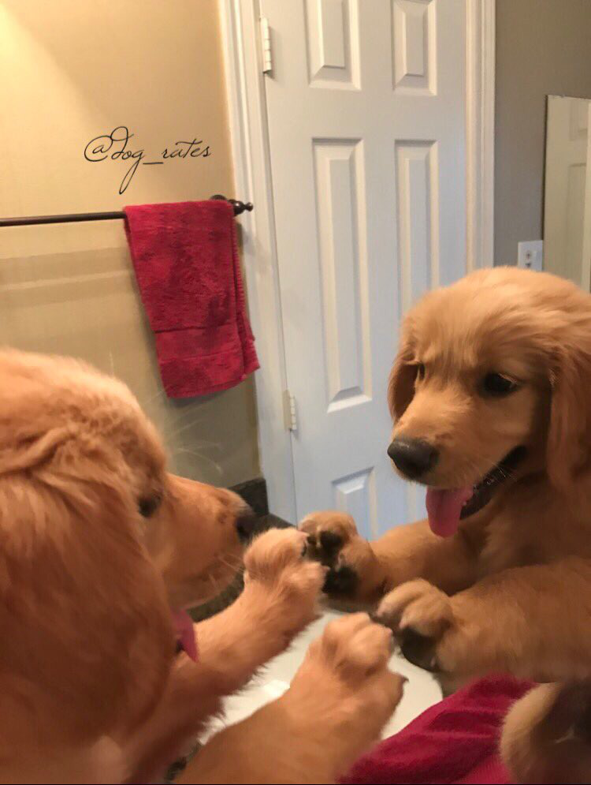

```python
#first the best Breed probability (Golden Retriever)with high confidence

url = master_cleaned.jpg_url[440]
r = requests.get(url)
Image.open(BytesIO(r.content))
```

observation: using the prediction 1 dog to verify that the image is truly a golden retriever and is true with a high prediction confidence of above0.99

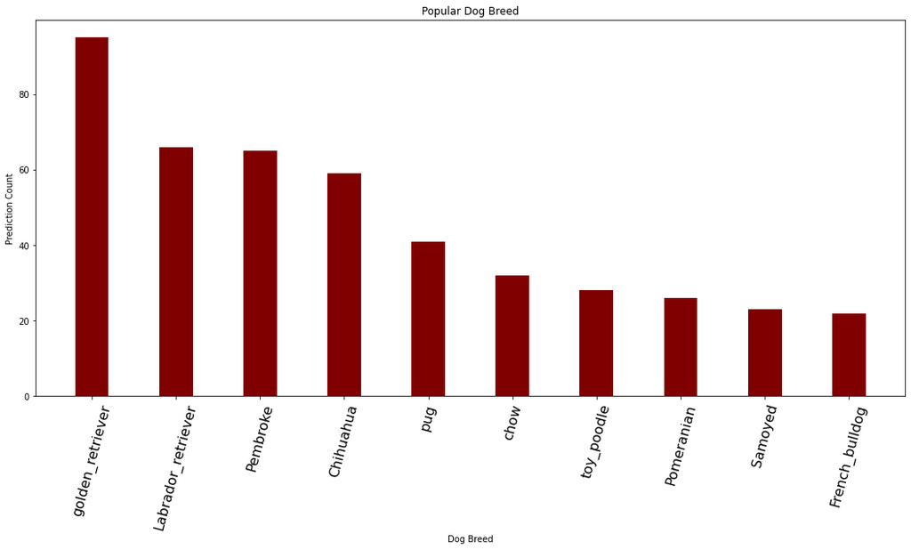

```python
# getting the dog breed with the highest fequency count
#slicing to get the topmost 10
fig = plt.figure(figsize = (18, 8))
x = master_cleaned['Prediction1'].value_counts()[:10].index
y =master_cleaned['Prediction1'].value_counts()[:10]
plt.bar(x,y,data = master_cleaned,width =0.4,color ='maroon');
plt.xlabel("Dog Breed");
plt.ylabel("Prediction Count");
plt.title("Popular Dog Breed");
plt.xticks(rotation=75,fontsize=16);
plt.show();
```

Obsevation:

THis showing the most frequent dog prediction for a given dog is golden retriever followed by labrador retriever